# Diabetes project

## Diabetes case study

This case study is about analyzing the dataset that contains details about diabetes. This kaggle [dataset](https://www.kaggle.com/houcembenmansour/predict-diabetes-based-on-diagnostic-measures) is originally from National institute of Diabetes and Digestive and Kidney diseases. This dataset has details like patient number,age,weight,bmi,cholesterol,pressure and whether the patient has diabetes or not.

#### Business Task:

To identify the different parameters from the given varaiables that contribute to diabetes.

#### Importing the packages

In order to analyze, clean and visualize the data, I am importing numpy,pandas,matplotlib and seaborn packages.

```python
import numpy as np
import pandas as pd
import matplotlib.pyplot as plt
import seaborn as sns
from pandas_profiling import ProfileReport

%matplotlib inline
```

#### Importing the dataset

Importing the diabetes dataset into a dataframe and previewing first 5 lines of dataset.

```python
diab_df = pd.read_csv('C:/Users/senth/Downloads/diabetes.csv')
```

#### Data Cleaning

```python
diab_df.head()
```

|  | patient_number | cholesterol | glucose | hdl_chol | chol_hdl_ratio | age | gender | height | weight | bmi | systolic_bp | diastolic_bp | waist | hip | waist_hip_ratio | diabetes |
| --- | --- | --- | --- | --- | --- | --- | --- | --- | --- | --- | --- | --- | --- | --- | --- | --- |
| 0 | 1 | 193 | 77 | 49 | 3,9 | 19 | female | 61 | 119 | 22,5 | 118 | 70 | 32 | 38 | 0,84 | No diabetes |
| 1 | 2 | 146 | 79 | 41 | 3,6 | 19 | female | 60 | 135 | 26,4 | 108 | 58 | 33 | 40 | 0,83 | No diabetes |
| 2 | 3 | 217 | 75 | 54 | 4 | 20 | female | 67 | 187 | 29,3 | 110 | 72 | 40 | 45 | 0,89 | No diabetes |
| 3 | 4 | 226 | 97 | 70 | 3,2 | 20 | female | 64 | 114 | 19,6 | 122 | 64 | 31 | 39 | 0,79 | No diabetes |
| 4 | 5 | 164 | 91 | 67 | 2,4 | 20 | female | 70 | 141 | 20,2 | 122 | 86 | 32 | 39 | 0,82 | No diabetes |

```python
diab_df.dtypes
```

```
patient_number      int64
cholesterol         int64
glucose             int64
hdl_chol            int64
chol_hdl_ratio     object
age                 int64
gender             object
height              int64
weight              int64
bmi                object
systolic_bp         int64
diastolic_bp        int64
waist               int64
hip                 int64
waist_hip_ratio    object
diabetes           object
dtype: object
```

By observing the data types of the different columns we can see that chol_hdl_ratio,bmi,waist_hip_ratio are objects when that should be numeric. Lets convert the datatype of those columns.

```python
diab_df['chol_hdl_ratio'] = diab_df['chol_hdl_ratio'].str.replace(',','.')
diab_df['bmi'] = diab_df['bmi'].str.replace(',','.')
diab_df['waist_hip_ratio'] = diab_df['waist_hip_ratio'].str.replace(',','.')
```

```python
diab_df[['chol_hdl_ratio','bmi','waist_hip_ratio']] = diab_df[['chol_hdl_ratio','bmi','waist_hip_ratio']].apply(pd.to_numeric)
```

```python
diab_df.dtypes
```

```
patient_number       int64
cholesterol          int64
glucose              int64
hdl_chol             int64
chol_hdl_ratio     float64
age                  int64
gender              object
height               int64
weight               int64
bmi                float64
systolic_bp          int64
diastolic_bp         int64
waist                int64
hip                  int64
waist_hip_ratio    float64
diabetes            object
dtype: object
```

```python
ProfileReport(diab_df)
```

Report generated with pandas-profiling.

By using pandas profiling , i observed if there are any missing values or duplicate values in any of the columns. There are no missing or duplicate values in the dataset. Some statistic summaries are available from pandas profiling which shows relation between different variables.

#### Analyzing and Visualizing the data

I want to find the range of glucose reading in the patients .

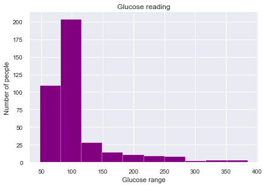

```python
fig,ax = plt.subplots(nrows = 1, ncols = 1)
plt.hist(diab_df['glucose'],color='purple')
fig.tight_layout()
plt.title('Glucose reading')
plt.xlabel('Glucose range')
plt.ylabel('Number of people')
plt.figure(figsize=(10,10))
```

From this glucose range histogram, I find that most of the patients glucose reading is in the normal range of less than 140 mg/dl. So I want to find the number of people with diabetes.

[output not shown]

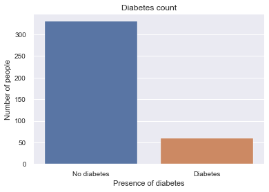

```python
sns.set_style('darkgrid')
sns.set_palette('deep')
sns.countplot(data=diab_df,x='diabetes').set(title='Diabetes count',xlabel='Presence of diabetes',ylabel='Number of people')
```

0f the 390 patients , 60 patients are diabetic. I filtered the dataframe to create a new dataframe containing only diabetic patient details.

```python
diab= diab_df[diab_df['diabetes'] == 'Diabetes']
```

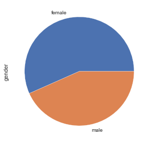

```python
fig = diab['gender'].value_counts().plot.pie().get_figure()
fig.tight_layout()
```

From this pie chart ,we can see that the number of female diabetic patients is more than the male diabetic patients. Next I want to find whether diabetes is widespread in older people or young people.

```
[Text(0.5, 1.0, 'Diabetes age range')]
```

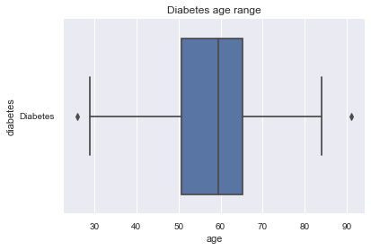

```python
sns.set_style('darkgrid')
sns.boxplot(x='age',y='diabetes',data = diab).set(title='Diabetes age range')
```

From the above boxplot, it is clear that old people between the age 50 to 65 are diabetic with some outlier patients having diabetes before the age of 30 and after the age of 90.

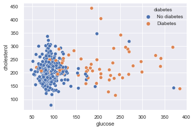

```python
sns.scatterplot(x=diab_df['glucose'],y=diab_df['cholesterol'],hue=diab_df['diabetes'])
```

```
[Text(0.5, 1.0, 'Bmi vs Diabetes'), Text(0.5, 0, 'Presence of diabetes')]
```

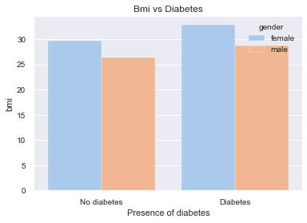

```python
sns.set_style('darkgrid')
sns.set_palette('pastel')
sns.barplot(x='diabetes',y='bmi',hue='gender', data= diab_df,ci=None).set(title='Bmi vs Diabetes',xlabel='Presence of diabetes')
```

When looking at the bmi of diabetic and non-diabetic patients, we can clearly see that the bmi of diabetic patients are more than the bmi of non-diabetic patients. So I visualized the relation between bmi and weight of the diabetic patients.

[figure not shown]

```python
sns.scatterplot(y='weight',x='bmi',hue='gender',data=diab)
```

From the above scatter plot we can see that the bmi increases as the weight of the patient increases . We have a positive linear correlation between the 2 variables.